# Closing Thoughts

## Complete Your Student Ratings!

https://studentratings.byu.edu/

## Ask Yourself the Following

Did I use AI to complete the assignment, or did AI complete the assignment for me?

- Review your work. Make sure you incorporate *originality* and *creativity* in the analysis **and** your recommendations.

Did I provide commentary for *every* decision in my analysis?

- Review your work. Add comments and descriptions of every piece of code!

## Ask Yourself the Following (Pt. 2)

Is the workflow in my analysis consistent with what we learned in class?

- You will not be penalized for adding extra steps as long as you provide justification.
- You *will* be penalized for omitting important steps (*e.g.*,
  - data cleaning
  - data exploration
  - data pre-processing/feature engineering (including splitting the data)
  - etc.

## Ask Yourself the Following (Pt. 3)

Is my executive summary distinct from my technical report?

- Your **technical report** provides all the context for your decisions.
- Your **executive summary** should focus on recommendations and insights. Only add data descriptions and context *where absolutely necessary*.

## Ask Yourself the Following (Pt. 4)

Did I turn in my QMD file, rendered QMD file, and executive summary?

## Questions?

## You Did It!!

Give yourselves a round of applause!

## Some Statistics

Approximately 165 quiz submissions.

Approximately 165 project submissions (by the end of the course).

Approximately 990 exercise submissions!

## Closing Thoughts Pt. 1

One of my very valuable teaching assistants has asked me to share some thoughts…

1. **Stay curious**. Ask *why* the data looks the way it does. Ask *what* could happen if you made a different choice.
2. **Think like a decision-maker**. Numbers matter, but so does the story. Learn to communicate your findings clearly and confidently.
3. **Don’t fear complexity but seek clarity**. Models can be powerful, but the most valuable insights are the ones people can understand and act on.
4. **Keep learning**. Tools will change—today it’s R, Python, Tableau; tomorrow it might be something else. But your ability to think analytically and make sense of the noise? That’s your superpower.

## Sincerely,

[figure not shown]

## Request for Closing Remarks from ChatGPT

“Pretend that you are a very valuable tutor for a marketing analytics class. The students have been coming to you for help throughout the semester, but the class is coming to an end. Do you have any last thoughts/closing remarks for your students?”

## (Actual) TA Advice!

- Preserve your agency! Tools (like AI) should help us do a *better* job, not do the job for us.
- Never stop learning (eternal progression)
- Everyone has different skills and rates at which they learn - don’t give up just because you think someone does something better than you!

## (Actual) TA Advice (Pt. 2)!

- Don’t be afraid to explore new things and pivot when you need to! Jobs, internships, skillsets, etc. can all change!
- Be relentless in your pursuit of truth. How? Ask questions!

## (Actual) TA Advice (Pt. 3)!

- **Show Up**. Nobody has everything (or maybe anything) figured out. If you show up, put in effort, be kind, and be humble - you will go far.
- The need for people who *actually* care has never been greater. You can grab some low hanging fruit if you just show up and give some effort.

## (Actual) TA Advice (Pt. 4)!

- Hold fiercely to your commitments! This builds invaluable trust.
- You reap what you sow. Effort and work will outperform natural talent in the long run.
- Any experience is good experience. Be grateful for opportunities.

## Do You Sometimes Feel Like This?

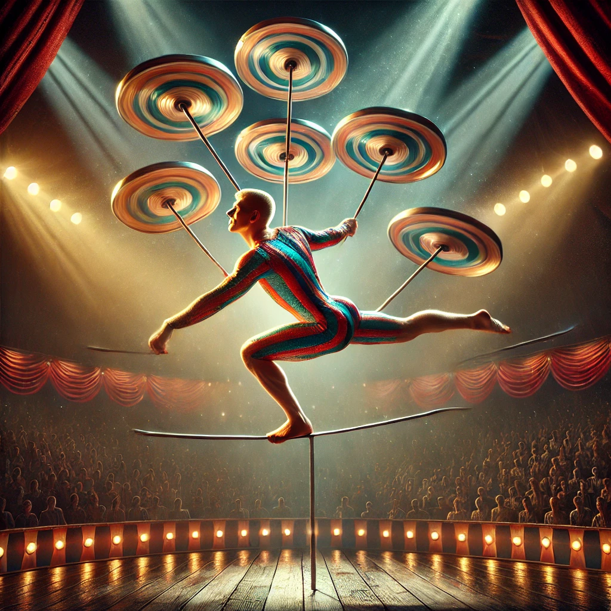

## Balance is Bogus!

https://www.youtube.com/watch?v=aVYPEjTiOmo

## Final Thoughts

“The gospel of Jesus Christ is a gospel of high ideals. Many of us are drawn to the Savior precisely because He lifts our sights and our aspirations high above and beyond anything the world has to offer.”

[Joyfully Receive the Unexpected Messiah](https://speeches.byu.edu/talks/dieter-f-uchtdorf/joyfully-receive-the-unexpected-messiah/), Dieter F. Uchtdorf, April 2025.

## Final Thoughts

“…it shouldn’t come as a surprise that [gospel ideals] don’t always match the messy, mundane realities of mortality…So what do we do when the beautiful, universal, eternal ideals of the gospel clash with the painful, individual, mortal realities of life?”

[Joyfully Receive the Unexpected Messiah](https://speeches.byu.edu/talks/dieter-f-uchtdorf/joyfully-receive-the-unexpected-messiah/), Dieter F. Uchtdorf, April 2025.

## Final Thoughts

- Never give up on the *ideal*.
- Don’t disregard the *real*.

“If you wait for sorrow to end before you experience joy, you might miss joy completely. To experience a measure of sorrow may enable your heart and mind to receive pure heavenly joy!”

[Joyfully Receive the Unexpected Messiah](https://speeches.byu.edu/talks/dieter-f-uchtdorf/joyfully-receive-the-unexpected-messiah/), Dieter F. Uchtdorf, April 2025.

## Final Thoughts

“How is that possible? The answer comes - as answers so often do - from Jesus Christ and the plan of happiness given by the Father. To use Eve’s words, it is

‘the joy of our redemption, and the eternal life which God giveth unto all the obedient.’”

[Joyfully Receive the Unexpected Messiah](https://speeches.byu.edu/talks/dieter-f-uchtdorf/joyfully-receive-the-unexpected-messiah/), Dieter F. Uchtdorf, April 2025.

## Assist Others in Their Quest For Eternal Life

“The key, it seems to me, is to know and understand your own capabilities and limitations and then to pace yourself, allocating and prioritizing your time, your attention, and your resources to wisely help others, including your family, in their quest for eternal life.”

“Oh Be Wise”, Elder M. Russell Ballard, Nov. 2006.